# Evaluation of Definition Structure

J. Allen Baron

Created: 2022-04-06 Updated: 2024-09-16

# Purpose

To better understand the style of definitions used within the Human Disease Ontology, particularly with regard to “characterized by” statements.

# Background

The definition [style guide](https://docs.google.com/document/d/1YUv_7noj3JJIuSSECU3ufAbXvDiPTugIDv7Dm0mRypw) indicates that definitions should always begin with their parent term and a description of the disease’s etiology (cause).

Lynn has explained that definitions frequently use “characterized by”, but it’s not clear to me if this should preface the etiology or signs/symptoms, and “has_material_basis_in”, which as I understand it is only used when a genetic cause is identified.

```r
repo <- DOrepo("~/Documents/Ontologies/HumanDiseaseOntology")
q <- "
    PREFIX rdfs: <http://www.w3.org/2000/01/rdf-schema#>
    PREFIX owl: <http://www.w3.org/2002/07/owl#>
    PREFIX oio: <http://www.geneontology.org/formats/oboInOwl#>
    PREFIX IAO: <http://purl.obolibrary.org/obo/IAO_>

    SELECT ?id ?label ?obs ?def ?parent_label
    WHERE {
        ?c IAO:0000115 ?def ;
            oio:id ?id ;
            rdfs:label ?label;
            rdfs:subClassOf ?parent .
        ?parent rdfs:label ?parent_label .
        FILTER(CONTAINS(STR(?c), 'DOID'))
        FILTER(!ISBLANK(?parent))
        OPTIONAL { ?c owl:deprecated ?obs . }
    }"

def <- repo$doid$query(q) %>%
    tibble::as_tibble() %>%
    tidyr::unnest(obs, keep_empty = TRUE) %>%
    dplyr::mutate(
        obs = dplyr::if_else(is.na(obs), FALSE, as.logical(obs)),
        cb_format = stringr::str_extract(def, "(that is )?characterized by"),
        chr_by = stringr::str_extract(def, "characterized by.*") %>%
            stringr::str_squish()
    ) %>%
    dplyr::arrange(id)
```

# Questions and Analysis

## “characterized by”

1. How many definitions use “characterized by” and do the majority use the format “that is characterized by” or just “characterized by”?

```r
dplyr::count(def, obs, cb_format) %>%
    add_percent(n)
```

| obs | cb_format | n | pct |
| --- | --- | --- | --- |
| FALSE | characterized by | 3714 | 27.30 |
| FALSE | that is characterized by | 3263 | 23.99 |
| FALSE | NA | 6627 | 48.71 |

The “characterized by” statement appears in about 1/2 of the non-obsolete definitions, with both formats used equally.

2. Is there a difference in format based on when a term was created? *Newer terms can be identified by a leading “0”.*

```r
def <- def %>%
    dplyr::mutate(newer = stringr::str_detect(id, "DOID:0"))

def %>%
    dplyr::filter(!obs) %>%
    dplyr::count(newer, cb_format) %>%
    add_percent(n)
```

| newer | cb_format | n | pct |
| --- | --- | --- | --- |
| FALSE | characterized by | 481 | 3.54 |
| FALSE | that is characterized by | 1118 | 8.22 |
| FALSE | NA | 2637 | 19.38 |
| TRUE | characterized by | 3233 | 23.77 |
| TRUE | that is characterized by | 2145 | 15.77 |
| TRUE | NA | 3990 | 29.33 |

Newer IDs more often use “characterized by” without the “that is”.

**PREFER format without “that is”.**

**NOTE 2024-09-16, JAB:** Lynn has said she prefers to include ‘that is’ before ‘characterized by’ but I still don’t use it for brevity’s sake and sticking with the more common pattern.

3. What is the “characterized by” statement for?

```r
def %>%
    dplyr::filter(!is.na(chr_by)) %>%
    dplyr::select(chr_by)
```

| chr_by |
| --- |
| characterized by a triangular tissue growth located_in cornea of the eye that is the result of collagen degeneration and fibrovascular proliferation. |
| characterized by deterioration of the function of the heart muscle. |
| characterized by deterioration of the function of the heart muscle. |
| characterized by a build up of plaque in the arteries. |
| characterized by inflammation of the blood vessels. |
| characterized by blistered skin as a result of self-reactive T and B cells that target BP180. |
| characterized by hypoglycemia caused by antibodies to insulin. |
| characterized by back pain, perineal pain, pain with ejaculation, hematospermia and voiding symptoms resulting from inflammation located_in the seminal vesicles caused by Neisseria gonorrhoeae infecti… |
| characterized by abnormal mineral metabolism. |
| characterized by a cardiomyopathy secondary to selenium deficiency. |

[output cut: 990 more lines]

There is a mix of its use preceding a list of symptoms/phenotypes/signs and use preceding a cause. I’ll need to ask for clarification on the preference.

**The consensus is that “characterized by” should precede a list of symptoms/phenotypes/signs.**

4. Where does “characterized by” usually occur in a definition? Or, in other words, how many words precede “characterized by”?

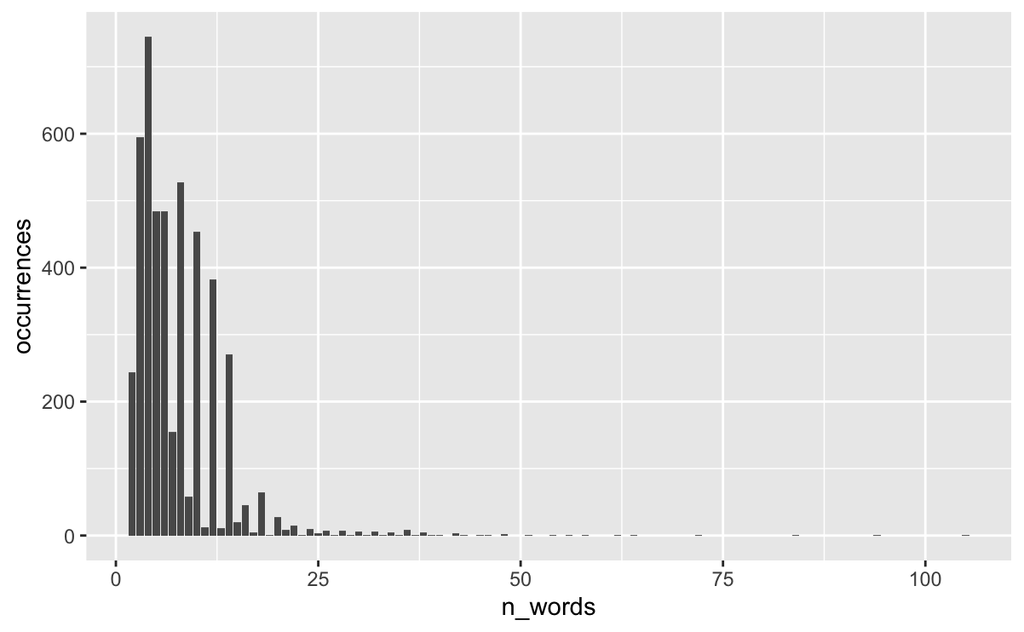

```r
def %>%
    dplyr::mutate(
        before_cb = stringr::str_extract(
            def,
            ".*?characterized by"
        ) %>%
            stringr::str_remove("(that is )characterized by")
    ) %>%
    dplyr::select(id, before_cb) %>%
    dplyr::filter(!is.na(before_cb)) %>%
    tidytext::unnest_tokens(
        output = "word",
        input = before_cb,
        token = "words"
    ) %>%
    dplyr::count(id, name = "n_words") %>%
    dplyr::count(n_words, name = "occurrences") %>%
    ggplot() +
    geom_col(aes(x = n_words, y = occurrences))
```

Most often the “characterized by” is the fourth or fifth word which means it’s generally at the beginning of a definition, probably right after the “A {parent}” statement.

**“characterized by” should generally be at the start of a definition.**

### Syndromes (and “characterized by”)

1. What about “characterized by” statements for syndromes?

```r
syndrome_q <- "
    PREFIX rdfs: <http://www.w3.org/2000/01/rdf-schema#>
    PREFIX owl: <http://www.w3.org/2002/07/owl#>
    PREFIX oio: <http://www.geneontology.org/formats/oboInOwl#>
    PREFIX IAO: <http://purl.obolibrary.org/obo/IAO_>
    PREFIX DOID: <http://purl.obolibrary.org/obo/DOID_>

    SELECT ?id ?label ?obs ?def
    WHERE {
        ?c IAO:0000115 ?def ;
            oio:id ?id ;
            rdfs:label ?label ;
            rdfs:subClassOf DOID:225 .
        OPTIONAL { ?c owl:deprecated ?obs . }
    }"

syn_def <- repo$doid$query(syndrome_q) %>%
    tibble::as_tibble() %>%
    tidyr::unnest(obs, keep_empty = TRUE) %>%
    dplyr::mutate(
        obs = dplyr::if_else(is.na(obs), FALSE, as.logical(obs)),
        cb_format = stringr::str_extract(def, "(that is )?characterized by"),
        chr_by = stringr::str_extract(def, "characterized by.*") %>%
            stringr::str_squish()
    ) %>%
    dplyr::arrange(id)
```

```r
count(syn_def, obs, cb_format)
```

| obs | cb_format | n |
| --- | --- | --- |
| FALSE | characterized by | 242 |
| FALSE | that is characterized by | 165 |
| FALSE | NA | 30 |

“characterized by” is *VERY* common for syndromes.

2. What about syndromes in name ONLY for which causes are known? *(i.e. those not in the syndrome branch of DO but with “syndrome” in their name)*

```r
def <- def %>%
    dplyr::mutate(
        syndrome_in_name = stringr::str_detect(label, "[Ss]yndrome"),
        true_syndrome = id %in% syn_def$id
    )

def %>%
    dplyr::filter(!obs) %>%
    dplyr::count(syndrome_in_name, true_syndrome) %>%
    add_percent(n)
```

| syndrome_in_name | true_syndrome | n | pct |
| --- | --- | --- | --- |
| FALSE | FALSE | 11423 | 83.97 |
| FALSE | TRUE | 163 | 1.20 |
| TRUE | FALSE | 1394 | 10.25 |
| TRUE | TRUE | 624 | 4.59 |

About 10% of disease are syndromes in name only, which is about twice as many as the true syndromes.

```r
sino <- def %>%
    dplyr::filter(syndrome_in_name, !true_syndrome, !obs)

sino %>%
    dplyr::count(cb_format) %>%
    add_percent(n)
```

| cb_format | n | pct |
| --- | --- | --- |
| characterized by | 442 | 31.71 |
| that is characterized by | 435 | 31.21 |
| NA | 517 | 37.09 |

Most still have “characterized by” in their definitions.

```r
sino %>%
    dplyr::select(def)
```

| def |
| --- |
| A dengue disease that involves the most severe form of dengue fever, has_material_basis_in Dengue virus [NCBITaxon:12637] with four serotypes (Dengue virus 1, 2, 3 and 4), which are transmitted_by Aed… |
| A primary ciliary dyskinesia that is characterized by sinusitis, bronchiectasis and situs inversus with dextrocardia resulting from dysfunction of the cilia during embryologic development. |
| An autoimmune polyendocrine syndrome that is inherited in an autosomal recessive fashion, which is characterized by abnormal functioning of the immune system that causes auto-reactivity against endocr… |
| An autoimmune polyendocrine syndrome that is characterized by abnormal functioning of the immune system that causes auto-reactivity against endocrine organs. It is more heterogeneous and has not been … |
| A neuromuscular junction disease that is characterized by an abnormality of acetylcholine (ACh) release at the neuromuscular junction which results from an autoimmune attack against voltage-gated calc… |
| A neuromuscular junction disease that is characterized by an abnormality of acetylcholine (ACh) release at the neuromuscular junction which results from an autoimmune attack against voltage-gated calc… |
| A neuromuscular junction disease that is characterized by an abnormality of acetylcholine (ACh) release at the neuromuscular junction which results from an autoimmune attack against voltage-gated calc… |
| A syndrome that has_material_basis_in heterozygous mutation in the tyrosine kinase domain of the FGFR2 gene on chromosome 10q26 and that is characterized by autosomal dominant inheritance of abnormali… |
| A syndrome that has_material_basis_in heterozygous mutation in the tyrosine kinase domain of the FGFR2 gene on chromosome 10q26 and that is characterized by autosomal dominant inheritance of abnormali… |
| A central nervous system disease characterized by throbbing, pulling creeping or other unpleasant sensations in the legs and the irresistible urge to move them. |

[output cut: 990 more lines]

It seems like “Budd-Chiari syndrome” (DOID:11512) really is a syndrome (no known cause). Maybe some of these should also be classified as syndromes?

3. How many syndromes *in name only* have causes identified?

```r
sino_cause <- sino %>%
    dplyr::filter(stringr::str_detect(def, "from"))

sino_cause
```

| id | label | obs | def | parent_label | cb_format | chr_by | newer | syndrome_in_name | true_syndrome |
| --- | --- | --- | --- | --- | --- | --- | --- | --- | --- |
| DOID:0050144 | Kartagener syndrome | FALSE | A primary ciliary dyskinesia that is characterized by sinusitis, bronchiectasis and situs inversus with dextrocardia resulting from dysfunction of the cilia during embryologic development. | primary ciliary dyskinesia | that is characterized by | characterized by sinusitis, bronchiectasis and situs inversus with dextrocardia resulting from dysfunction of the cilia during embryologic development. | TRUE | TRUE | FALSE |
| DOID:0050214 | Lambert-Eaton myasthenic syndrome | FALSE | A neuromuscular junction disease that is characterized by an abnormality of acetylcholine (ACh) release at the neuromuscular junction which results from an autoimmune attack against voltage-gated calc… | autoimmune disease of peripheral nervous system | that is characterized by | characterized by an abnormality of acetylcholine (ACh) release at the neuromuscular junction which results from an autoimmune attack against voltage-gated calcium channels (VGCC) on the presynaptic mo… | TRUE | TRUE | FALSE |
| DOID:0050214 | Lambert-Eaton myasthenic syndrome | FALSE | A neuromuscular junction disease that is characterized by an abnormality of acetylcholine (ACh) release at the neuromuscular junction which results from an autoimmune attack against voltage-gated calc… | autoimmune disease of musculoskeletal system | that is characterized by | characterized by an abnormality of acetylcholine (ACh) release at the neuromuscular junction which results from an autoimmune attack against voltage-gated calcium channels (VGCC) on the presynaptic mo… | TRUE | TRUE | FALSE |
| DOID:0050214 | Lambert-Eaton myasthenic syndrome | FALSE | A neuromuscular junction disease that is characterized by an abnormality of acetylcholine (ACh) release at the neuromuscular junction which results from an autoimmune attack against voltage-gated calc… | neuromuscular junction disease | that is characterized by | characterized by an abnormality of acetylcholine (ACh) release at the neuromuscular junction which results from an autoimmune attack against voltage-gated calcium channels (VGCC) on the presynaptic mo… | TRUE | TRUE | FALSE |
| DOID:0050432 | Asperger syndrome | FALSE | An autism spectrum disorder that is characterized by significant difficulties in social interaction, along with restricted and repetitive patterns of behavior and interests. It differs from other auti… | autism spectrum disorder | that is characterized by | characterized by significant difficulties in social interaction, along with restricted and repetitive patterns of behavior and interests. It differs from other autism spectrum disorders by its relativ… | TRUE | TRUE | FALSE |
| DOID:0050450 | Gitelman syndrome | FALSE | A renal tubular transport disease that is has_material_basis_in mutations in genes that produce proteins involved in the kidneys' reabsorption of salt (sodium chloride or NaCl) from urine back into th… | autosomal recessive disease | NA | NA | TRUE | TRUE | FALSE |
| DOID:0050450 | Gitelman syndrome | FALSE | A renal tubular transport disease that is has_material_basis_in mutations in genes that produce proteins involved in the kidneys' reabsorption of salt (sodium chloride or NaCl) from urine back into th… | renal tubular transport disease | NA | NA | TRUE | TRUE | FALSE |
| DOID:0050693 | Brooke-Spiegler syndrome | FALSE | A skin disease that is characterized by the development of several types of tumors from the skin, has_material_basis_in heterozygous mutation in the CYLD gene on chromosome 16q12. | skin disease | that is characterized by | characterized by the development of several types of tumors from the skin, has_material_basis_in heterozygous mutation in the CYLD gene on chromosome 16q12. | TRUE | TRUE | FALSE |
| DOID:0050693 | Brooke-Spiegler syndrome | FALSE | A skin disease that is characterized by the development of several types of tumors from the skin, has_material_basis_in heterozygous mutation in the CYLD gene on chromosome 16q12. | autosomal dominant disease | that is characterized by | characterized by the development of several types of tumors from the skin, has_material_basis_in heterozygous mutation in the CYLD gene on chromosome 16q12. | TRUE | TRUE | FALSE |
| DOID:0050786 | iridogoniodysgenesis syndrome | FALSE | An iris disease that is characterized by the iris stroma being hypoplastic resulting from abnormalities in the differentiation of the anterior segment structures and increased values of intraocular pr… | autosomal dominant disease | that is characterized by | characterized by the iris stroma being hypoplastic resulting from abnormalities in the differentiation of the anterior segment structures and increased values of intraocular pressure and has_material_… | TRUE | TRUE | FALSE |

[output cut: 52 more lines]

About 62.

**Generally syndromes start with a “characterized by” list, which may be followed by the cause if known.**

## NOT “characterized by”

1. When would a “characterized by” statement be *inappropriate*?

```r
no_cb <- def %>%
    dplyr::filter(is.na(chr_by)) %>%
    dplyr::select(def)
no_cb
```

| def |
| --- |
| A vascular cancer that derives_from the cells that line the walls of blood vessels or lymphatic vessels. |
| A disease that involving errors in metabolic processes of building or degradation of molecules. |
| A crustacean allergy that has_allergic_trigger shrimp. |
| A drug allergy that has_allergic_trigger acetylsalicylic acid. |
| A beta-lactam allergy that has_allergic_trigger benzylpenicillin. |
| A beta-lactam allergy that has_allergic_trigger amoxicillin. |
| A cephalosporin allergy that has_allergic_trigger ceftriaxone. |
| A drug allergy that has_allergic_trigger carbamazepine. |
| A drug allergy that has_allergic_trigger abacavir. |
| A drug allergy that has_allergic_trigger isoniazide. |

[output cut: 990 more lines]

Allergies, autoimmune diseases, and infectious diseases do not appear to use “characterized by” statements.

2. When “characterized by” is absent, what follows the “parent” statement?

```r
no_cb <- def %>%
    dplyr::filter(is.na(chr_by)) %>%
    dplyr::mutate(
        after_parent = purrr::map2_chr(
            .x = def,
            .y = parent_label,
            ~ stringr::str_extract(.x, paste0(.y, ".*")) %>%
                stringr::str_remove(.y) %>%
                stringr::str_squish()
        )
    ) %>%
    dplyr::select(id, after_parent) %>%
    dplyr::filter(!is.na(after_parent))

no_cb_word <- no_cb %>%
    tidytext::unnest_tokens(
        output = "word",
        input = after_parent,
        token = "words"
    ) %>%
    dplyr::group_by(id) %>%
    dplyr::mutate(pos = dplyr::row_number()) %>%
    dplyr::ungroup() %>%
    dplyr::count(pos, word) %>%
    dplyr::arrange(pos, dplyr::desc(n)) %>%
    dplyr::group_by(pos) %>%
    dplyr::mutate(rank = dplyr::row_number(rev(n))) %>%
    dplyr::ungroup() %>%
    dplyr::filter(rank <= 10, pos < 4) %>%
    add_percent(n, pos)

no_cb_word %>%
    dplyr::filter(rank < 6) %>%
    dplyr::select(pos, word, pct) %>%
    tidyr::pivot_wider(
        names_from = pos,
        values_from = pct
    )
```

| word | 1 | 2 | 3 |
| --- | --- | --- | --- |
| that | 93.36 | NA | NA |
| which | 1.43 | NA | NA |
| located_in | 1.31 | NA | 13.18 |
| and | 0.81 | NA | NA |
| triggered | 0.79 | NA | NA |
| has_material_basis_in | NA | 55.30 | NA |
| is | NA | 20.28 | NA |
| involves | NA | 7.56 | NA |
| results_in | NA | 4.65 | NA |
| derives_from | NA | 3.60 | NA |

[output cut: 4 more lines]

It seems that aside from “characterized by” the other major statements are primarily attached with “that” and include: “has_material_basis_in” > “located_in” > “involves” > “results_in” > “derives_from”.

The patterns may be easier to view as 3-grams (the first 3 words as a set) where those with relationship terms (identifiable by the presence of an underscore) have all following words removed in order to collapse them together. I think it would also be worth including “characterized by” to find out where it fits in terms of use frequency.

```r
def %>%
    dplyr::mutate(
        after_parent = purrr::map2_chr(
            .x = def,
            .y = parent_label,
            ~ stringr::str_extract(.x, paste0(.y, ".*")) %>%
                stringr::str_remove(.y) %>%
                stringr::str_squish()
        )
    ) %>%
    dplyr::select(id, after_parent) %>%
    dplyr::filter(!is.na(after_parent)) %>%
    dplyr::mutate(
        after_parent = stringr::str_replace_all(
            after_parent,
            c(
                "located in" = "located_in",
                "results in" = "results_in",
                "(that is ?)characterized[ _]+by" = "characterized_by",
                "characterized by" = "characterized_by"
            )
        )
    ) %>%
    tidytext::unnest_ngrams(output = "three", input = after_parent, n = 3) %>%
    dplyr::mutate(
        three = stringr::str_replace(
            three,
            "(.*_[a-z]+).*",
            "\\1"
        )
    ) %>%
    dplyr::group_by(id) %>%
    dplyr::filter(dplyr::row_number() == 1) %>%
    dplyr::ungroup() %>%
    dplyr::count(three, sort = TRUE) %>%
    add_percent(n)
```

| three | n | pct |
| --- | --- | --- |
| characterized_by | 4222 | 48.02 |
| that has_material_basis_in | 2220 | 25.25 |
| that is located_in | 380 | 4.32 |
| that results_in | 258 | 2.93 |
| that derives_from | 142 | 1.62 |
| that is a | 121 | 1.38 |
| that has_allergic_trigger | 86 | 0.98 |
| that is characterized | 75 | 0.85 |
| located_in | 70 | 0.80 |
| that involves the | 41 | 0.47 |

[output cut: 526 more lines]

Ultimately it seems like the most frequent statements (ranked) are as follows:

**characterized by >> has_material_basis_in >> located_in > results_in > derives_from > is a > has_allergic_trigger**

Some less frequently used statements use: involves > arises from > affects > composed of

3. What is included in the “is a” statement?

```r
no_cb %>%
    dplyr::mutate(
        is_a = stringr::str_extract(after_parent, "that is a ([^ ]+ ){2}") %>%
            stringr::str_remove("that is a ")
    ) %>%
    dplyr::filter(!is.na(is_a)) %>%
    dplyr::count(is_a, sort = TRUE)
```

| is_a | n |
| --- | --- |
| loss of | 25 |
| hemorrhagic fever, | 12 |
| benign tumor | 4 |
| sexually transmitted | 3 |
| polyp that | 2 |
| soft tissue | 2 |
| superficial fungal | 2 |
| type of | 2 |
| zoonotic infection | 2 |
| zoonotic infectious | 2 |

[output cut: 50 more lines]

It appears that it is primarily used in place of one of the more common statements.

**“that is a” should be avoided and used in only rare instances.**

## “caused by”

1. How are “caused by” statements used?

```r
def <- def %>%
    dplyr::mutate(
        caused = stringr::str_extract(def, "caused by.*") %>%
            stringr::str_squish(),
        has_caused = !is.na(caused)
    )

count(def, obs, has_caused) %>%
    add_percent(n)
```

| obs | has_caused | n | pct |
| --- | --- | --- | --- |
| FALSE | FALSE | 13217 | 97.16 |
| FALSE | TRUE | 387 | 2.84 |

```r
count(def, newer, has_caused) %>%
    add_percent(n)
```

| newer | has_caused | n | pct |
| --- | --- | --- | --- |
| FALSE | FALSE | 3969 | 29.18 |
| FALSE | TRUE | 267 | 1.96 |
| TRUE | FALSE | 9248 | 67.98 |
| TRUE | TRUE | 120 | 0.88 |

These statements are not common. They’re use has declined in non-obsolete, newer terms.

**NOTE 2022-04-04, JAB:** Lynn stated “caused by” should generally be avoided.

## Parentheses & Terminology

1. Should definitions include words in parentheses?

```r
def <- def %>%
    dplyr::mutate(
        has_paren = stringr::str_detect(def, "\\(\\w+"),
        paren_content = stringr::str_extract_all(def, "\\(.+?\\)") %>%
            purrr::map_chr(DO.utils::collapse_to_string)
    )

dplyr::count(def, has_paren) %>%
    add_percent(n)
```

| has_paren | n | pct |
| --- | --- | --- |
| FALSE | 12503 | 91.91 |
| TRUE | 1101 | 8.09 |

Most often they **do not** include parentheses but they do exist.

2. Are medical terms or their explanations included in parentheses?

Looking at content…

```r
dplyr::filter(def, has_paren) %>%
    dplyr::select(paren_content)
```

| paren_content |
| --- |
| (Amblyomma americanum) |
| (Ixodes scapularis)\|(Ixodes pacificus)\|(Ixodes ricinus) |
| (Amblyomma hebraeum and Amblyomma variegatum) |
| (Rhipicephalus pumilio and Rhipicephalus sanguineus)\|(usually single) |
| (Rhipicephalus sanguineus) |
| (Rhipicephalus sanguineus) |
| (Haemaphysalis concinna) |
| (Amblyomma cajennense) |
| (Dermacentor taiwanensis and Haemaphysalis flava) |
| (Amblyomma maculatum) |

[output cut: 990 more lines]

The first few are scientific genus species names and I know there are gene names. Quantifying those…

```r
dplyr::filter(def, has_paren) %>%
    dplyr::mutate(
        is_species = stringr::str_detect(def, "\\([A-Z][a-z]+ [a-z]+"),
        is_gene = stringr::str_detect(def, "\\([A-Z0-9]{3,}")
    ) %>%
    dplyr::summarize(
        species = sum(is_species),
        gene = sum(is_gene),
        other = sum(!is_gene & !is_species)
    )
```

| species | gene | other |
| --- | --- | --- |
| 42 | 550 | 509 |

Reviewing content that are not genes or species names…

```r
def %>%
    dplyr::mutate(
        is_species = stringr::str_detect(def, "\\([A-Z][a-z]+ [a-z]+"),
        is_gene = stringr::str_detect(def, "\\([A-Z0-9]{3,}")
    ) %>%
    dplyr::filter(has_paren, !is_species, !is_gene) %>%
    dplyr::select(paren_content)
```

| paren_content |
| --- |
| (e.g., pancreatic disease or Coeliac disease)\|(which work to alleviate constipation by drawing water into the bowels) |
| (hypermotility) |
| (BoNTA, B, E and F) |
| (touch)\|(smell) |
| (alveoli)\|(malaise)\|(called Velcro crackles) |
| (IgM) |
| (coenurus) |
| (coenurus) |
| (coenurus) |
| (surgery) |

[output cut: 499 more lines]

There **are** medical terms or their explanations in parentheses. There’s not a neat regular expression pattern to identify and quantify them, but the number relative to the total number of definitions is proportionally low suggesting a preference **not** to use them. But again, I’ll need to ask for clarification as all versions exist.

**The preference should be use of medical terms over layman’s terms but it is not a hard and fast rule.**

## Common N-grams

The goal here is to identify common usage among definitions irrespective of order to try identify all words/2-grams/3-grams that serve to delineate statements.

1. What are the top 20 words (excluding stop words)?

```r
word <- def %>%
    dplyr::select(id, def) %>%
    tidytext::unnest_tokens(
        output = "word",
        input = "def",
        token = "words"
    ) %>%
    dplyr::anti_join(tidytext::stop_words, by = "word")

word_count <- word %>%
    dplyr::count(word, name = "freq", sort = TRUE) %>%
    add_percent(freq)

word_count %>%
    dplyr::filter(dplyr::row_number() <= 20)
```

| word | freq | pct |
| --- | --- | --- |
| has_material_basis_in | 8400 | 3.91 |
| characterized | 7149 | 3.33 |
| chromosome | 6805 | 3.17 |
| mutation | 6694 | 3.11 |
| gene | 6662 | 3.10 |
| heterozygous | 4237 | 1.97 |
| homozygous | 2929 | 1.36 |
| disease | 2544 | 1.18 |
| compound | 2185 | 1.02 |
| syndrome | 1873 | 0.87 |

[output cut: 10 more lines]

Visualizing more results as a word cloud…

```r
word_count %>%
    dplyr::mutate(
        word = stringr::str_replace(
            word,
            "has_material_basis_in",
            "has_mat_basis"
        )
    ) %>%
    wordcloud2::wordcloud2(size = 0.5, fontWeight = "normal")
```

[interactive chart not shown]

2. What are the top 2-grams?

```r
g2 <- def %>%
    dplyr::select(id, def) %>%
    tidytext::unnest_ngrams(
        output = "ngram",
        input = "def",
        n = 2
    )

g2 <- g2 %>%
    dplyr::count(ngram, name = "freq", sort = TRUE) %>%
    add_percent(freq)

g2 %>%
    dplyr::filter(dplyr::row_number() <= 20)
```

| ngram | freq | pct |
| --- | --- | --- |
| in the | 7873 | 2.40 |
| that has_material_basis_in | 7088 | 2.16 |
| characterized by | 7008 | 2.14 |
| on chromosome | 6387 | 1.95 |
| mutation in | 6303 | 1.92 |
| gene on | 5585 | 1.70 |
| that is | 4751 | 1.45 |
| heterozygous mutation | 3940 | 1.20 |
| is characterized | 3523 | 1.07 |
| of the | 3152 | 0.96 |

[output cut: 10 more lines]

2. What are the top 3-grams?

```r
g3 <- def %>%
    dplyr::select(id, def) %>%
    tidytext::unnest_ngrams(
        output = "ngram",
        input = "def",
        n = 3
    )

g3 <- g3 %>%
    dplyr::count(ngram, name = "freq", sort = TRUE) %>%
    add_percent(freq)

g3 %>%
    dplyr::filter(dplyr::row_number() <= 20)
```

| ngram | freq | pct |
| --- | --- | --- |
| mutation in the | 5835 | 1.86 |
| gene on chromosome | 5561 | 1.77 |
| heterozygous mutation in | 3917 | 1.25 |
| is characterized by | 3410 | 1.08 |
| that is characterized | 3371 | 1.07 |
| that has_material_basis_in homozygous | 2491 | 0.79 |
| compound heterozygous mutation | 2097 | 0.67 |
| or compound heterozygous | 1996 | 0.63 |
| homozygous or compound | 1990 | 0.63 |
| has_material_basis_in homozygous or | 1885 | 0.60 |

[output cut: 10 more lines]

That apparently is not a very useful exercise.

## Genetic Information

Not all “has_material_basis_in” used in definitions refer to a genetic basis and no one term or pattern exists to identify all of these. Most, if not all, can be matched with a search for words like mutation, gene, chromosome, etc. The breakdown of matches used to identify genetic “has_material_basis_in” definitions is as follows (with some definitions having multiple matches):

```r
tmp <- def %>%
    dplyr::select(id:def) %>%
    dplyr::mutate(
        genetic_basis = stringr::str_extract_all(
            def,
            "(mut|vari)ation|chromosom|inherit| gene |[0-9]+[pq][0-9]+"
        ) %>%
            purrr::map_chr(
                ~ stringr::str_replace_all(.x, "[0-9]+[pq][0-9]+", "chrom_loc") %>%
                    unique() %>%
                    sort() %>%
                    DO.utils::vctr_to_string(delim = " | ")
            )
    ) %>%
    dplyr::filter(
        stringr::str_detect(def, "material[ _]basis[ _]"),
        genetic_basis != ""
    )

tmp %>%
    dplyr::count(genetic_basis) %>%
    inflate_col_(genetic_basis) %>%
    dplyr::count(genetic_basis, wt = n, sort = TRUE)
```

| genetic_basis | n |
| --- | --- |
| mutation | 6793 |
| chromosom | 6709 |
| chrom_loc | 6121 |
| gene | 6095 |
| inherit | 893 |
| variation | 294 |

Combined, those patterns identify 4,451 (of 9,314) definitions with genetic bases (~ 47.8%).

The most common patterns are as follows:

```r
hmbi <- tmp %>%
    dplyr::mutate(
        hmbi = stringr::str_remove(def, ".*basis[ _]in[ _]+"),
        # replace gene symbols with placeholder
        hmbi = stringr::str_replace_all(
            hmbi,
            c(" [A-Z0-9\\-]{3,}([ .,])" = " GENE_SYM\\1",
              " [X0-9]+[pq][0-9.]*([ .,])" = " CHROM_SYM\\1")
        )
    )
```

```r
words <- hmbi %>%
    dplyr::select(label, hmbi) %>%
    tidytext::unnest_tokens(hmbi, output = "words") %>%
    dplyr::group_by(label) %>%
    dplyr::mutate(pos = dplyr::row_number()) %>%
    dplyr::ungroup()

words %>%
    dplyr::group_by(pos, words) %>%
    dplyr::summarize(n = length(words)) %>%
    dplyr::mutate(
        rank = dplyr::row_number(dplyr::desc(n)),
        words = paste0(words, " (", n, ")")
    ) %>%
    dplyr::ungroup() %>%
    dplyr::arrange(pos, rank) %>%
    dplyr::select(-n) %>%
    tidyr::pivot_wider(id_cols = rank, names_from = pos, values_from = words)
```

| rank | 1 | 2 | 3 | 4 | 5 | 6 | 7 | 8 | 9 | 10 | 11 | 12 | 13 | 14 | 15 | 16 | 17 | 18 | 19 | 20 | 21 | 22 | 23 | 24 | 25 | 26 | 27 | 28 | 29 | … |
| --- | --- | --- | --- | --- | --- | --- | --- | --- | --- | --- | --- | --- | --- | --- | --- | --- | --- | --- | --- | --- | --- | --- | --- | --- | --- | --- | --- | --- | --- | --- |
| 1 | homozygous (1583) | mutation (1566) | in (1550) | the (1485) | gene_sym (1373) | gene (1371) | on (1332) | chromosome (1331) | chrom_sym (1345) | on (963) | chromosome (985) | chrom_sym (1001) | the (859) | gene_sym (851) | gene (857) | on (876) | chromosome (878) | chrom_sym (887) | the (708) | gene_sym (695) | gene (689) | on (699) | chromosome (698) | chrom_sym (697) | chromosome (77) | chrom_sym (74) | chrom_sym (34) | the (37) | chromosome (35) | … |
| 2 | heterozygous (1037) | or (1139) | compound (1079) | heterozygous (1081) | mutation (1151) | in (1179) | the (1097) | gene_sym (1033) | gene (1029) | heterozygous (538) | mutation (839) | in (841) | homozygous (621) | or (623) | compound (623) | heterozygous (633) | mutation (684) | in (700) | chromosome (148) | chrom_sym (153) | chromosome (142) | chrom_sym (145) | gene (68) | on (74) | on (32) | the (34) | the (29) | on (33) | the (35) | … |
| 3 | mutation (667) | in (894) | the (872) | gene_sym (690) | gene (644) | on (548) | chromosome (563) | chrom_sym (527) | mutation (351) | in (384) | the (368) | gene_sym (321) | gene (326) | on (340) | chromosome (347) | chrom_sym (348) | the (143) | on (144) | gene (127) | on (140) | the (75) | gene_sym (68) | gene_sym (45) | gene (46) | the (32) | chromosome (31) | chromosome (24) | in (32) | mutation (26) | … |
| 4 | autosomal (217) | autosomal (145) | inheritance (212) | mutation (234) | of (161) | the (248) | gene_sym (318) | gene (268) | on (264) | chromosome (285) | chrom_sym (250) | chromosome (100) | mutation (104) | in (111) | mutation (162) | in (112) | gene (97) | gene_sym (127) | mutation (58) | in (70) | in (48) | the (56) | the (39) | in (29) | in (26) | in (31) | gene (24) | chrom_sym (24) | gene_sym (24) | … |
| 5 | variation (197) | recessive (126) | mutation (103) | of (194) | region (154) | gene_sym (144) | gene (146) | on (219) | chromosome (188) | homozygous (244) | on (92) | on (81) | chrom_sym (88) | chrom_sym (93) | the (111) | gene_sym (105) | gene_sym (72) | heterozygous (48) | in (42) | the (38) | gene_sym (32) | in (32) | in (23) | gene_sym (23) | mutation (25) | or (25) | in (23) | gene_sym (22) | in (24) | … |
| 6 | an (142) | heterozygous (102) | dominant (86) | chromosome (157) | the (130) | chrom_sym (124) | in (131) | the (145) | gene_sym (104) | chrom_sym (206) | gene_sym (76) | heterozygous (80) | chromosome (86) | heterozygous (78) | in (84) | of (97) | chrom_sym (53) | gene (46) | heterozygous (34) | mutation (37) | mutation (28) | gene (30) | of (19) | the (23) | gene_sym (22) | gene_sym (24) | heterozygous (21) | heterozygous (21) | gene (23) | … |
| 7 | a (110) | dominant (93) | of (77) | in (117) | on (111) | chromosome (109) | chrom_sym (100) | in (73) | the (78) | gene (99) | homozygous (50) | or (52) | autosomal (68) | mutation (63) | on (57) | the (66) | on (44) | the (37) | gene_sym (25) | gene (32) | of (22) | chromosome (19) | heterozygous (17) | heterozygous (21) | homozygous (22) | on (24) | gene_sym (20) | mutation (21) | heterozygous (13) | … |
| 8 | hemizygous (102) | of (68) | recessive (76) | region (62) | in (110) | mutation (101) | compound (44) | heterozygous (71) | in (62) | the (79) | in (49) | the (52) | compound (53) | chromosome (46) | chrom_sym (43) | chromosome (62) | in (35) | mutation (36) | chrom_sym (21) | heterozygous (24) | on (19) | of (17) | mutation (16) | or (21) | gene (21) | mutation (23) | mutation (20) | of (18) | and (9) | … |
| 9 | compound (89) | linked (31) | a (61) | a (37) | heterozygous (61) | or (51) | variation (34) | mutation (30) | encoding (31) | gene_sym (55) | compound (48) | an (50) | heterozygous (49) | gene (46) | gene_sym (40) | gene (40) | heterozygous (31) | chromosome (35) | on (18) | of (23) | and (17) | mutation (16) | chrom_sym (15) | of (20) | or (20) | gene (20) | of (19) | or (16) | of (8) | … |
| 10 | mutations (72) | homozygous (17) | heterozygous (39) | gene (35) | homozygous (61) | encoding (33) | mutation (32) | variation (19) | of (21) | hemizygous (53) | gene (46) | gene (48) | gene_sym (42) | homozygous (43) | or (40) | or (29) | of (22) | of (21) | and (16) | chromosome (20) | chrom_sym (15) | or (15) | homozygous (15) | mutation (17) | of (18) | compound (14) | compound (18) | and (13) | or (8) | … |

[output cut: 310 more lines]

```r
g3 <- hmbi %>%
    dplyr::select(label, hmbi) %>%
    tidytext::unnest_ngrams(hmbi, n = 3, output = "words", to_lower = FALSE) %>%
    dplyr::group_by(label) %>%
    dplyr::mutate(pos = dplyr::row_number()) %>%
    dplyr::ungroup()

dplyr::count(g3, words, sort = TRUE)
```

| words | n |
| --- | --- |
| on chromosome CHROM_SYM | 6206 |
| the GENE_SYM gene | 5869 |
| mutation in the | 5815 |
| gene on chromosome | 5529 |
| in the GENE_SYM | 5528 |
| GENE_SYM gene on | 5402 |
| heterozygous mutation in | 3900 |
| compound heterozygous mutation | 2095 |
| or compound heterozygous | 1994 |
| homozygous or compound | 1988 |

[output cut: 990 more lines]

The major pattern BY FAR is probably “has_material_basis_in mutation in the {GENE SYMBOL} gene on chromosome {CYTOGENETIC LOCATION}.” It’s challenging to know how often gene names are included but it might be possible to measure how often the gene symbol appears without the gene name.

```r
hmbi %>%
    dplyr::mutate(
        gene_phrase = stringr::str_extract(
            hmbi,
            "([A-Za-z0-9._\\-,]+ ){0,3}genes?( [A-Za-z0-9._\\-,]+){0,3}"
        )
    ) %>%
    dplyr::count(gene_phrase, sort = TRUE) %>%
    dplyr::mutate(pct = round(n / sum(n) * 100, 2))
```

| gene_phrase | n | pct |
| --- | --- | --- |
| in the GENE_SYM gene on chromosome CHROM_SYM. | 4664 | 62.83 |
| NA | 946 | 12.74 |
| of the GENE_SYM gene on chromosome CHROM_SYM. | 291 | 3.92 |
| in the GENE_SYM gene | 270 | 3.64 |
| in the GENE_SYM gene on chromosome CHROM_SYM | 155 | 2.09 |
| gene on chromosome CHROM_SYM. | 51 | 0.69 |
| in the GENE_SYM gene on chromosome CHROM_SYM, | 49 | 0.66 |
| gene | 18 | 0.24 |
| in the GENE_SYM gene on CHROM_SYM. | 10 | 0.13 |
| of the GENE_SYM gene | 10 | 0.13 |

[output cut: 510 more lines]

```r
gene_id <- hmbi %>%
    dplyr::mutate(
        gene_id = stringr::str_extract(hmbi,"the.*gene|gene for .*")
    ) %>%
    dplyr::count(gene_id, sort = TRUE) %>%
    dplyr::mutate(pct = round(n / sum(n) * 100, 2))

gene_id
```

| gene_id | n | pct |
| --- | --- | --- |
| the GENE_SYM gene | 5586 | 75.25 |
| NA | 1031 | 13.89 |
| the gene | 172 | 2.32 |
| the GENE_SYM and GENE_SYM gene | 14 | 0.19 |
| the GENE_SYM gene on chromosome CHROM_SYM or the GENE_SYM gene | 14 | 0.19 |
| the GENE_SYM or GENE_SYM gene | 11 | 0.15 |
| the GENE_SYM gene on chromosome CHROM_SYM, sometimes in association with mutation in another gene | 10 | 0.13 |
| the GENE_SYM gene on chromosome CHROM_SYM Biallelic mutation in the GENE_SYM gene | 9 | 0.12 |
| the 5-prime untranslated region of the GENE_SYM gene | 8 | 0.11 |
| the GENE_SYM gene on chromosome CHROM_SYM, sometimes in association with mutations in other gene | 8 | 0.11 |

[output cut: 303 more lines]

### Inheritance

Sometimes diseases caused by the same gene are differentiated by OMIM based on inheritance (and possibly phenotype). Generally, OMIM uses “heterozygous” vs “homozygous” in definitions to describe variants and that basically corresponds to dominant vs recessive inheritance but they aren’t the same. Prompted by these concerns, an exploration of inheritance terminology in definitions follows.

**Question: How is inheritance described in definitions?**

NOTE: Deprecated terms are excluded from analysis.

First, we’ll need to identify which inheritance terms/phrases exist.

```r
def_inherit <- def %>%
    dplyr::select(id:parent_label) %>%
    dplyr::filter(!obs) %>%
    dplyr::mutate(
        term = stringr::str_extract_all(
            def,
            DO.utils::collapse_to_string(
                "(",
                "autosom[^ ]*( [^ [:punct:]]*)|",
                "[^ ]*link[^ ]*|",
                "[^ ]*genic[^ [:punct:]]*|", # many "genic" words --> limit
                "de novo",
                ")+", # keep adjacent matching terms together
                delim = ""
            )
        ),
        term = purrr::map_chr(
            term,
            ~ stringr::str_trim(.x) %>%
                DO.utils::collapse_to_string(unique = TRUE, na.rm = TRUE)
        )
    ) %>%
    dplyr::filter(!is.na(term))

dplyr::count(def_inherit, term) %>%
    dplyr::arrange(term)
```

| term | n |
| --- | --- |
| N-linked | 1 |
| Pathogenic | 2 |
| Phacogenic | 1 |
| X-linked | 279 |
| X-linked\|monogenic | 2 |
| Y-linked | 2 |
| amyloidogenic | 5 |
| anamyloidogenic | 3 |
| arrhythmogenic | 23 |
| autosomal domiant | 2 |

[output cut: 42 more lines]

1. It looks like it’s common to have a combination of 5 words together related to autosomal inheritance in various arrangement: autosomal, recessive, dominant, inheritance, and gene plus derivatives.
   - I wonder what the more complete ‘autosomal gene(s|tic)’ phrases are?
2. Need to limit the ‘link’ search to include just ‘[XY]-’ before (or nothing) and only the word boundary/-ed/-age after.
3. Need to limit the ‘genic’ search to just the mono-/di-/poly-/inter- set.

Refining that search a bit based on those observations, returns:

```r
def_inherit <- def %>%
    dplyr::select(id:parent_label) %>%
    dplyr::filter(!obs) %>%
    dplyr::mutate(
        term = stringr::str_extract_all(
            def,
            DO.utils::collapse_to_string(
                "(",
                "(\\b(autosom|recess|domi|gene|inher)[a-z]*\\b ?)+|",
                "[XY].?link(ed|age)?\\b|",
                "(inter|mono|di|poly)genic\\b|", # many "genic" words --> limit
                "de novo\\b",
                ")+", # keep adjacent matching terms together
                delim = ""
            )
        ),
        term = purrr::map_chr(
            term,
            ~ stringr::str_trim(.x) %>%
                DO.utils::collapse_to_string(unique = TRUE, na.rm = TRUE)
        )
    ) %>%
    dplyr::filter(!is.na(term))

dplyr::count(def_inherit, term) %>%
    dplyr::arrange(term)
```

| term | n |
| --- | --- |
| X-linked | 61 |
| X-linked\|dominant inheritance | 1 |
| X-linked\|dominant inheritance\|gene | 10 |
| X-linked\|dominant\|gene | 2 |
| X-linked\|gene | 118 |
| X-linked\|generally | 2 |
| X-linked\|genes | 3 |
| X-linked\|inheritance | 23 |
| X-linked\|inheritance\|gene | 17 |
| X-linked\|inherited\|gene | 1 |

[output cut: 120 more lines]

That captured the autosomal phrases better except for the expansion of ‘gene’-derived terms. I think the word gene itself is used widely and not relevant to this examination. Allowing derivatives generally also added irrelevant terms, so ‘gene’ and its derivatives should probably be limited further and only included when following an autosomal phrase.

Also, it seems that X/Y-linked should be added the variable set of autosomal words to capture broader phrases. I’ll move it there and retain the ‘link(ed|age)’ as its own search to capture other ‘link’ terms, requiring that no letters come before to avoid overgeneralizing.

```r
def_inherit <- def %>%
    dplyr::select(id:parent_label) %>%
    dplyr::filter(!obs) %>%
    dplyr::mutate(
        term = stringr::str_extract_all(
            def,
            DO.utils::collapse_to_string(
                "(",
                "(\\b(autosom|recess|domi|inher|[XY].?link(ed|age)?)[a-z]*\\b ?(gene[a-z]*)?)+|",
                "[^\\-]\\blink(ed|age)?\\b|",
                "(inter|mono|di|poly)genic\\b|", # many "genic" words --> limit
                "de novo\\b",
                ")+", # keep adjacent matching terms together
                delim = ""
            )
        ),
        term = purrr::map_chr(
            term,
            ~ stringr::str_trim(.x) %>%
                DO.utils::collapse_to_string(unique = TRUE, na.rm = TRUE)
        )
    ) %>%
    dplyr::filter(!is.na(term))

dplyr::count(def_inherit, term) %>%
    dplyr::arrange(term)
```

| term | n |
| --- | --- |
| X-linked | 186 |
| X-linked dominant | 2 |
| X-linked dominant inheritance | 11 |
| X-linked inheritance | 37 |
| X-linked inherited | 1 |
| X-linked monogenic\|dominant inheritance | 1 |
| X-linked monogenic\|recessive inheritance | 1 |
| X-linked recessive | 14 |
| X-linked recessive inheritance | 17 |
| X-linked recessive\|X-linked dominant | 2 |

[output cut: 53 more lines]

Need to remove standalone ‘linked’ that’s used too broadly and limit ‘recess’ to avoid ‘recession’.

```r
def_inherit <- def %>%
    dplyr::select(id:parent_label) %>%
    dplyr::filter(!obs) %>%
    dplyr::mutate(
        term = stringr::str_extract_all(
            def,
            DO.utils::collapse_to_string(
                "(",
                "(\\b(autosom|recessiv|(semi-)?domi|inher|[XY].?link(ed|age)?)[a-z]*\\b ?(gene[a-z]*)?)+|",
                "[^\\-]\\blinkage\\b|",
                "(inter|mono|di|poly)genic\\b|", # many "genic" words --> limit
                "de novo\\b",
                ")+", # keep adjacent matching terms together
                delim = ""
            )
        ),
        term = purrr::map_chr(
            term,
            ~ stringr::str_trim(.x) %>%
                DO.utils::collapse_to_string(unique = TRUE, na.rm = TRUE)
        )
    ) %>%
    dplyr::filter(!is.na(term))

dplyr::count(def_inherit, term) %>%
    dplyr::arrange(term)
```

| term | n |
| --- | --- |
| X-linked | 186 |
| X-linked dominant | 2 |
| X-linked dominant inheritance | 11 |
| X-linked inheritance | 37 |
| X-linked inherited | 1 |
| X-linked monogenic\|dominant inheritance | 1 |
| X-linked monogenic\|recessive inheritance | 1 |
| X-linked recessive | 14 |
| X-linked recessive inheritance | 17 |
| X-linked recessive\|X-linked dominant | 2 |

[output cut: 50 more lines]

That should do it.

Now to see the broader phrasing in which these inheritance terms are used. I’m going to exclude as much as I can those inheritance phrases that are at the beginning of the definition because they are part of the parent disease’s label, since these will not contribute to the understand of inheritance patterns in definitions.

```r
def_inherit <- def %>%
    dplyr::select(id:parent_label) %>%
    DO.utils::collapse_col(parent_label) %>%
    dplyr::filter(!obs) %>%
    dplyr::mutate(
        term = stringr::str_extract_all(
            def,
            DO.utils::collapse_to_string(
                "(",
                "(\\b(autosom|recessiv|(semi-)?domi|inher|[XY].?link(ed|age)?)[a-z]*\\b ?(gene[a-z]*)?)+|",
                "[^\\-]\\blinkage\\b|",
                "(inter|mono|di|poly)genic\\b|", # many "genic" words --> limit
                "de novo\\b",
                ")+", # keep adjacent matching terms together
                delim = ""
            )
        ),
        term = purrr::map(
            term,
            ~ stringr::str_trim(.x) %>%
                unique()
        ),
        term_n = purrr::map_int(term, length)
    ) %>%
    dplyr::filter(term_n > 0) %>%
    tidyr::unnest(term) %>%
    dplyr::mutate(
        phrase = purrr::map2(
            def,
            term,
            ~ tibble::tibble(
                before = stringr::str_extract_all(
                    .x,
                    paste0("([^ ]+[ [:punct:]]*){0,3}", .y)
                ),
                after = stringr::str_extract_all(
                    .x,
                    paste0(.y, "([ [:punct:]]*[^ ]+){0,3}")
                )
            )
        )
    ) %>%
    tidyr::unnest(phrase) %>%
    tidyr::unnest(c(before, after)) %>%
    # remove line where inheritance "term" is near beginning
    dplyr::filter(
        purrr::map2_lgl(
            def,
            before,
            ~ !stringr::str_detect(.x, paste0("^", stringr::str_escape(.y)))
        )
    )
```

The breakdown of text before each inheritance “term” is:

```r
def_inherit %>%
    dplyr::count(term, before, sort = TRUE)
```

| term | before | n |
| --- | --- | --- |
| autosomal dominant | that has_material_basis_in an autosomal dominant | 72 |
| autosomal recessive | that has_material_basis_in an autosomal recessive | 60 |
| autosomal recessive inheritance | is characterized by autosomal recessive inheritance | 47 |
| autosomal recessive inheritance | syndrome characterized by autosomal recessive inheritance | 25 |
| autosomal dominant inheritance | is characterized by autosomal dominant inheritance | 20 |
| autosomal dominant inheritance | syndrome characterized by autosomal dominant inheritance | 16 |
| autosomal recessive inheritance | disease characterized by autosomal recessive inheritance | 16 |
| autosomal dominant inheritance | disease characterized by autosomal dominant inheritance | 12 |
| dominant inheritance | syndrome that has_material_basis_in dominant inheritance | 11 |
| autosomal recessive inheritance | leukodystrophy characterized by autosomal recessive inheritance | 10 |

[output cut: 387 more lines]

Hmmm… looks like a lot of “has_material_basis_in” and “characterized by” but the exact counts of those are split due to other text variations. Focusing on those two “terms”, the counts become:

```r
def_inherit <- def_inherit %>%
    dplyr::mutate(b_common = stringr::str_extract(before, "has_material_basis_in|characterized by"))

def_inherit %>%
    dplyr::count(term, b_common, sort = TRUE) %>%
    dplyr::group_by(b_common) %>%
    dplyr::summarize(
        term = DO.utils::unique_to_string(term, delim = "|", sort = TRUE),
        n = sum(n)
    ) %>%
    dplyr::ungroup() %>%
    dplyr::arrange(dplyr::desc(n)) %>%
    add_percent(.col = n)
```

| b_common | term | n | pct |
| --- | --- | --- | --- |
| has_material_basis_in | autosomal dominant\|autosomal dominant de novo\|autosomal dominant inheritance\|autosomal recessive\|autosomal recessive inheritance\|de novo\|digenic\|dominant\|dominant inheritance\|dominantly inher… | 453 | 54.06 |
| characterized by | autosomal\|autosomal domiant inheritance\|autosomal dominant\|autosomal dominant inheritance\|autosomal inheritance\|autosomal recessive\|autosomal recessive inheritance\|autosomal recessive inhertita… | 293 | 34.96 |
| NA | autosomal dominant\|autosomal dominant genetic\|autosomal dominant inheritance\|autosomal gene\|autosomal recessive\|autosomal recessive inheritance\|de novo\|digenic\|dominant\|dominantly\|inheritanc… | 92 | 10.98 |

More than half come after “has_material_basis_in” but a sizable amount also follow “characterized by”.

What about the text **after** the inheritance phrase?

The breakdown of text after each inheritance “term” is:

```r
def_inherit %>%
    dplyr::count(term, after, sort = TRUE)
```

| term | after | n |
| --- | --- | --- |
| autosomal dominant | autosomal dominant mutation of the | 74 |
| autosomal recessive | autosomal recessive mutation of the | 53 |
| autosomal recessive inheritance | autosomal recessive inheritance of homozygous or | 43 |
| autosomal recessive inheritance | autosomal recessive inheritance of mutation in | 33 |
| autosomal dominant inheritance | autosomal dominant inheritance of heterozygous mutation | 32 |
| autosomal dominant inheritance | autosomal dominant inheritance of mutation in | 16 |
| autosomal dominant inheritance | autosomal dominant inheritance. | 14 |
| autosomal recessive inheritance | autosomal recessive inheritance. | 14 |
| autosomal recessive inheritance | autosomal recessive inheritance that has_material_basis_in homozygous | 13 |
| autosomal recessive inheritance | autosomal recessive inheritance that has_material_basis_in mutation | 13 |

[output cut: 400 more lines]

Looking at this it appears most common to include inheritance after has_material_basis_in but prior to description of the mutation type (homozygous/heterozygous/etc.).

We can assign patterns to different people by organizing by assigned range(s) of IDs (Lynn: 50000,50999 & 80000,85999; etc.).

```r
def_inherit <- def_inherit %>%
    dplyr::mutate(
        num_id = as.numeric(stringr::str_remove(id, ".+:")),
        creator = dplyr::case_when(
            num_id < 50000 ~ "pre-2015",
            dplyr::between(num_id, 50000, 50999) | dplyr::between(num_id, 80000, 85999) ~ "Lynn",
            num_id >= 110000 ~ "MODs",
            TRUE ~ "others"
        )
    )

dplyr::count(def_inherit, creator)
```

| creator | n |
| --- | --- |
| Lynn | 151 |
| MODs | 247 |
| others | 388 |
| pre-2015 | 52 |

And then look at trends in has_material_basis vs “characterized by” by author or group:

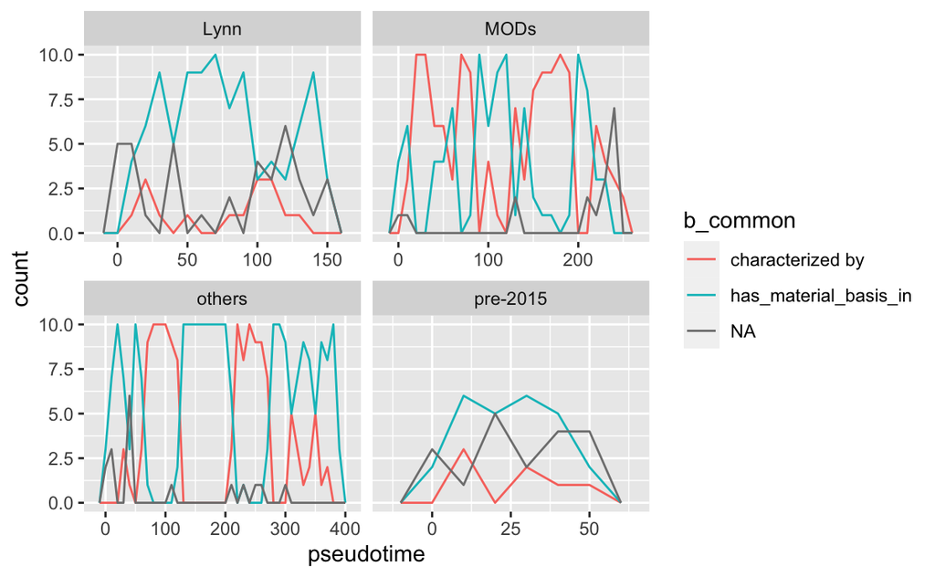

```r
def_inherit <- def_inherit %>%
    dplyr::group_by(creator) %>%
    dplyr::mutate(pseudotime = dplyr::row_number(num_id))

ggplot(def_inherit) +
    geom_freqpoly(aes(x = pseudotime, color = b_common), binwidth = 10) +
    facet_wrap(~ creator, scales = "free_x")
```

Hmmm… it seems pre-2015 additions and those made by Lynn are generally preferred to be made after ‘has_material_basis_in’ while the MODs and others are variable over time (possibly curator-linked).

Lynn’s most 5 recent additions by inheritance term include the following definitions:

```r
def_inherit %>%
    dplyr::filter(creator == "Lynn") %>%
    dplyr::mutate(
        group_term = dplyr::case_when(
            stringr::str_detect(term, "autosom|dom|rec") ~ "autosomal",
            stringr::str_detect(term, "[XY]-") ~ "sex-linked",
            stringr::str_detect(term, "inher") ~ "inheritance",
            TRUE ~ term
        )
    ) %>%
    dplyr::group_by(group_term) %>%
    dplyr::slice_max(pseudotime, n = 5) %>%
    dplyr::arrange(group_term, pseudotime) %>%
    dplyr::select(id, group_term, def) %>%
    kbl() %>%
    kable_paper() %>%
    column_spec(3, width = "30em")
```

| id | group_term | def |
| --- | --- | --- |
| DOID:0081340 | autosomal | A congenital myopathy that is characterized by severe congenital weakness usually resulting in death from respiratory failure in the first year or so of life and that has_material_basis_in heterozygou… |
| DOID:0081340 | autosomal | A congenital myopathy that is characterized by severe congenital weakness usually resulting in death from respiratory failure in the first year or so of life and that has_material_basis_in heterozygou… |
| DOID:0081374 | autosomal | A nemaline myopathy that has_material_basis_in autosomal recessive inheritance of a homozygous or compound heterozygous mutation in the TNNT1 gene on chromosome 19q13, with childhood onset. |
| DOID:0081375 | autosomal | A nemaline myopathy that has_material_basis_in autosomal dominant inheritance of a homozygous or compound heterozygous mutation in the TNNT1 gene on chromosome 19q13. |
| DOID:0081394 | autosomal | A syndrome that is characterized by the presence of associated congenital hepatic fibrosis and that is associated with autosomal recessive polycystic kidney disease. |
| DOID:0050120 | de novo | A lymphatic system disease that is characterized by an expansion of the monocyte-macrophage population and intense hemophagocytosis. It can occur de novo, but more often occurs in the setting of anoth… |
| DOID:0080565 | de novo | A congenital disorder of glycosylation I that is characterized by muscular hypotonia and ichthyosis and has_material_basis_in homozygous mutation in the DOLK gene, which encodes the enzyme responsible… |
| DOID:0081091 | de novo | An acute myeloid leukemia that is characterized by de novo RUNX1 gene mutation, not associated with myelodysplastic syndrome-related cytogenetic abnormalities. |
| DOID:0080952 | digenic | A syndrome that is characterized by global developmental delay with impaired intellectual development, onset of bone marrow failure and myelodysplastic syndrome in childhood, and poor overall growth w… |
| DOID:0080406 | inheritance | An orofacial cleft characterized by autosomal doninant inhertitance that has_material_basis_in variation in chromosome region 1p33 associated with enrichment of the T allele of SNP rs3827730. |
| DOID:0080682 | inheritance | An intestinal pseudo-obstruction that is inherited as an autosomal dominant trait. |
| DOID:0080714 | inheritance | A syndrome that is characterized by high blood tryptase levels and that has_material_basis_in inherited extra copies of the alpha tryptase gene (TPSAB1), effecting multiple organ systems including ski… |
| DOID:0080952 | inheritance | A syndrome that is characterized by global developmental delay with impaired intellectual development, onset of bone marrow failure and myelodysplastic syndrome in childhood, and poor overall growth w… |
| DOID:0081360 | inheritance | A spastic quadriplegic cerebral palsy that has_material_basis_in deletion of the ANKRD15 gene (KANK1) inherited on the paternal allele. |
| DOID:0081196 | linkage | An autosomal recessive intellectual developmental disorder that has_material_basis_in linkage to a 45.6-Mb interval in the pericentromeric region of chromosome 11 between SNPs rs604518 and rs10899421. |
| DOID:0081198 | linkage | An autosomal recessive intellectual developmental disorder that has_material_basis_in linkage to a 19.5-Mb region on chromosome 12q between SNPs rs4760658 and rs1882033. |
| DOID:0081199 | linkage | An autosomal recessive intellectual developmental disorder that has_material_basis_in linkage to a 4.4-Mb region on chromosome 6q between SNPs rs6935718 and rs388609. |
| DOID:0081201 | linkage | An autosomal recessive intellectual developmental disorder that has_material_basis_in linkage to a 12.2-Mb region on chromosome 17q21.31-q22 between SNPs rs4792947 and rs11079258. |
| DOID:0081367 | linkage | A Paget's disease of bone that has_material_basis_in linkage to the 5q31 region within 12.2 cM, between D5S642 and D5S1972. |
| DOID:0080319 | sex-linked | A T cell deficiency that is characterized by CD4 lymphopenia, severe chronic viral infections, and defective T-lymphocyte activation in males and has_material_basis_in X-linked inheritance of mutation… |
| DOID:0080982 | sex-linked | A syndromic X-linked intellectual disability that is characterized primarily by severe mental retardation, dysmorphic facies, and a highly skewed X-inactivation pattern in carrier women and that has_m… |
| DOID:0080982 | sex-linked | A syndromic X-linked intellectual disability that is characterized primarily by severe mental retardation, dysmorphic facies, and a highly skewed X-inactivation pattern in carrier women and that has_m… |
| DOID:0081043 | sex-linked | A fetal akinesia deformation sequence syndrom that is an X-linked form that is characterized by brain malformations, telecanthus, and narrow palpebral fissures. |
| DOID:0081059 | sex-linked | A central diabetes insipidus that has_material_basis_in X-linked inheritance. |

### Genetic Phrasing

After exploring `has material basis in` statements, it’s clear that most have inheritance, specific genes and chromosomal location listed. There are some diseases that don’t have clear genes but most will have genetic (i.e. chromosomal) information.

**What patterns are there for definitions with chromosomal locations?**

*EXCLUDING OBSOLETE*

```r
chrom <- def %>%
    dplyr::filter(
        !obs,
        stringr::str_detect(def, "chromos")
    ) %>%
    dplyr::select(id, label, def) %>%
    dplyr::distinct() %>%
    tidytext::unnest_tokens(
        output = "word",
        input = def,
        token = "words",
        drop = FALSE
    ) %>%
    dplyr::group_by(id) %>%
    dplyr::mutate(pos = dplyr::row_number()) %>%
    dplyr::ungroup() %>%
    dplyr::anti_join(tidytext::stop_words, by = "word")
```

```r
# want to find the most common words --> small IDF
chrom_anal <- chrom %>%
    dplyr::count(id, def, word, sort = TRUE) %>%
    tidytext::bind_tf_idf(term = word, document = id, n = n) %>%
    dplyr::group_by(word, idf) %>%
    dplyr::summarize(
        id_n = dplyr::n_distinct(id),
        id_pct = round(id_n / dplyr::n_distinct(chrom$id) * 100, 1)
    ) %>%
    dplyr::ungroup() %>%
    dplyr::arrange(idf)

chrom_anal
```

| word | idf | id_n | id_pct |
| --- | --- | --- | --- |
| chromosome | 0.009903522 | 4019 | 99.0 |
| has_material_basis_in | 0.015392558 | 3997 | 98.5 |
| mutation | 0.122227487 | 3592 | 88.5 |
| gene | 0.138223339 | 3535 | 87.1 |
| heterozygous | 0.580276137 | 2272 | 56.0 |
| characterized | 0.590895706 | 2248 | 55.4 |
| homozygous | 0.901374206 | 1648 | 40.6 |
| compound | 1.220283138 | 1198 | 29.5 |
| autosomal | 1.487584445 | 917 | 22.6 |
| syndrome | 1.614129858 | 808 | 19.9 |

[output cut: 990 more lines]

```r
dplyr::filter(chrom_anal, str_detect(word, "chromos"), word != "chromosome")
```

| word | idf | id_n | id_pct |
| --- | --- | --- | --- |
| chromosomal | 3.744344 | 96 | 2.4 |
| chromosomes | 5.669635 | 14 | 0.3 |

‘gene’ is right up at the top along with other expected inheritance words. One interest I have is in understanding what words are used when ‘gene’ is not included.

```r
no_gene <- chrom %>%
    dplyr::group_by(id) %>%
    dplyr::filter(all(word != "gene")) %>%
    dplyr::ungroup() %>%
    dplyr::count(id, def, word, sort = TRUE) %>%
    tidytext::bind_tf_idf(term = word, document = id, n = n)

no_gene_idf <- no_gene %>%
    dplyr::group_by(word, idf) %>%
    dplyr::summarize(
        id_n = dplyr::n_distinct(id),
        id_pct = round(id_n / dplyr::n_distinct(no_gene$id) * 100, 1)
    ) %>%
    dplyr::ungroup() %>%
    dplyr::arrange(idf)

no_gene_idf
```

| word | idf | id_n | id_pct |
| --- | --- | --- | --- |
| has_material_basis_in | 0.05895617 | 494 | 94.3 |
| chromosome | 0.07117628 | 488 | 93.1 |
| region | 0.67424303 | 267 | 51.0 |
| characterized | 0.78085276 | 240 | 45.8 |
| mutation | 0.90963355 | 211 | 40.3 |
| variation | 1.04655593 | 184 | 35.1 |
| heterozygous | 1.41730460 | 127 | 24.2 |
| autosomal | 1.67652421 | 98 | 18.7 |
| syndrome | 1.71819690 | 94 | 17.9 |
| chromosomal | 1.89204383 | 79 | 15.1 |

[output cut: 990 more lines]

‘region’ > ‘mutation’ > ‘variation’ seem to be the most common genetic mutation/location words used when ‘gene’ is not. Other less frequent (< 10%) possibilities include ‘deletion’ > ‘locus’ > ‘duplication’ ~ ‘genes’ ~ ‘variable’ > ‘mb’ (assuming megabase) ~ ‘mapped’ ~ ‘linkage’ ~ ‘snps’ (i.e. SNPs)

With regard to ‘variation’ vs ‘variant’, etc. it appears that DO has a clear and definite preference for variation, not using ‘variant’ at all.

```r
dplyr::filter(no_gene_idf, stringr::str_detect(word, "^var"))
```

| word | idf | id_n | id_pct |
| --- | --- | --- | --- |
| variation | 1.046556 | 184 | 35.1 |
| variable | 3.428278 | 17 | 3.2 |
| varicella | 6.261492 | 1 | 0.2 |
| varying | 6.261492 | 1 | 0.2 |

I know from prior exploration that ‘gene’ is most frequently used in the phrase ‘the {SYMBOL} gene’.

**What about the phrases for ‘region’, ‘mutation’ and ‘variation’?**

```r
no_gene_phrase <- chrom %>%
    dplyr::filter(word %in% c('region', 'mutation', 'variation')) %>%
    dplyr::mutate(
        phrase = purrr::map2(
            def,
            word,
            ~ stringr::str_extract_all(
                .x,
                paste0("(?:\\w+ ){0,2}", .y, "(?: \\w+){0,2}")
            )
        )
    ) %>%
    tidyr::unnest(phrase) %>%
    tidyr::unnest(phrase) %>%
    dplyr::select(id, no_gene = word, phrase) %>%
    dplyr::distinct() %>%
    tidytext::unnest_tokens(
        output = "word",
        input = phrase,
        token = "words",
        to_lower = FALSE,
        drop = FALSE
    ) %>%
    dplyr::group_by(no_gene, id, phrase) %>%
    dplyr::mutate(pos = dplyr::row_number()) %>%
    dplyr::ungroup() %>%
    dplyr::filter(pos != 3)

ng_phrase_split <- no_gene_phrase %>%
    tidyr::nest(.by = no_gene) %>%
    tidyr::pivot_wider(names_from = no_gene, values_from = data) %>%
    unlist(recursive = FALSE)

ng_phrase_n <- ng_phrase_split %>%
    purrr::map(
        ~ dplyr::group_by(.x, pos, word) %>%
            dplyr::summarize(
                id_n = dplyr::n_distinct(id),
                id_pct = round(id_n / dplyr::n_distinct(.x$id) * 100, 1),
                .groups = "drop"
            ) %>%
            dplyr::arrange(pos, dplyr::desc(id_n))
    )
```

The most common words at each position surrounding one of these 3 terms can be seen below.

```r
ng_phrase_summary <- ng_phrase_n %>%
    purrr::map(
        ~ dplyr::group_by(.x, pos) %>%
            dplyr::mutate(
                max = max(id_pct),
                relevant = cumsum(id_pct) < 80,
                order = dplyr::row_number(-id_pct),
                sig_vs_prior = dplyr::if_else(
                    id_pct >= dplyr::lag(id_pct / 2, default = NA),
                    ">",
                    ">>"
                )
            ) %>%
            dplyr::ungroup() %>%
            dplyr::filter(relevant & order <= 5 | id_pct == max) %>%
            dplyr::select(-relevant)
    )

ng_phrase_summary %>%
    purrr::map(~ dplyr::select(.x, pos:id_pct))
```

| pos | word | id_n | id_pct |
| --- | --- | --- | --- |
| 1 | has_material_basis_in | 1497 | 41.7 |
| 1 | compound | 1152 | 32.1 |
| 2 | heterozygous | 2145 | 59.7 |
| 2 | has_material_basis_in | 550 | 15.3 |
| 4 | in | 3351 | 93.3 |
| 5 | the | 3360 | 93.5 |

| pos | word | id_n | id_pct |
| --- | --- | --- | --- |
| 1 | the | 150 | 50.7 |
| 1 | in | 74 | 25.0 |
| 1 | Mb | 10 | 3.4 |
| 2 | chromosome | 135 | 45.6 |
| 2 | a | 73 | 24.7 |
| 4 | on | 68 | 23.0 |
| 4 | of | 18 | 6.1 |
| 4 | chromosome | 9 | 3.0 |
| 4 | that | 4 | 1.4 |
| 4 | 18p11 | 3 | 1.0 |

[output cut: 5 more lines]

| pos | word | id_n | id_pct |
| --- | --- | --- | --- |
| 1 | that | 177 | 88.9 |
| 2 | has_material_basis_in | 182 | 91.5 |
| 4 | in | 189 | 95.0 |
| 5 | the | 159 | 79.9 |

```
NA
```

Simplifying these back into phrases makes the patterns more apparent.

```r
purrr::map2(
    ng_phrase_summary,
    names(ng_phrase_summary),
    ~ dplyr::group_by(.x, pos) %>%
        dplyr::summarize(
            pos_var = DO.utils::sandwich_text(
                stringr::str_trim(
                    paste(
                        dplyr::if_else(!is.na(sig_vs_prior), sig_vs_prior, ""),
                        word,
                        collapse = " "
                    )
                ),
                c("(", ")")
            )
        ) %>%
        { DO.utils::collapse_to_string(
            dplyr::filter(., pos < 3)$pos_var,
            .y,
            dplyr::filter(., pos > 3)$pos_var,
            delim = " "
        ) }
) %>%
    unlist() %>%
    unname()
```

```
[1] "(has_material_basis_in > compound) (heterozygous >> has_material_basis_in) mutation (in) (the)"
[2] "(the >> in >> Mb) (chromosome > a) region (on >> of >> chromosome >> that > 18p11) (chromosome >> the >> SNPs > a > as)"
[3] "(that) (has_material_basis_in) variation (in) (the)"
```

#### Variation, Gene Unknown

When a disease is linked to a specific region on a chromosome and no gene has been identified what is the appropriate pattern to use?

```r
hmbi_region <- hmbi %>%
    dplyr::filter(
        stringr::str_detect(def, "region|linkage"),
        # ignore gene-based hmbi statements
        !stringr::str_detect(hmbi, stringr::coll("GENE_SYM")),
        !stringr::str_detect(def, stringr::coll("gene")),
        # ignore deletions and duplications, which are a special case
        !stringr::str_detect(label, "deletion|duplication")
    ) %>%
    dplyr::mutate(
        # ignore chromosome and variant symbols & drop CHROM_SYM
        hmbi = stringr::str_replace_all(
            hmbi,
            "[YX0-9][pqter0-9_.-]+[^ ]*|CHROM_SYM[^ ]*",
            "..."
        )
    )

region_patterns <- dplyr::count(hmbi_region, hmbi, sort = TRUE) %>%
    dplyr::mutate(pct = round(n / sum(n) * 100, 2))
region_patterns
```

| hmbi | n | pct |
| --- | --- | --- |
| variation in the chromosome region ... | 167 | 48.41 |
| variation in the region ... | 24 | 6.96 |
| hemizygous mutation in a region on chromosome ... | 16 | 4.64 |
| variation in a region on chromosome ... | 16 | 4.64 |
| variation in the chromosomal region ... | 13 | 3.77 |
| autosomal dominant inheritance of variation in the chromosome region ... | 12 | 3.48 |
| heterozygous mutation in a region on chromosome ... | 12 | 3.48 |
| homozygous or compound heterozygous mutation in a region on chromosome ... | 9 | 2.61 |
| heterozygous mutation in a region of chromosome ... | 8 | 2.32 |
| mutation in a region on chromosome ... | 8 | 2.32 |

[output cut: 35 more lines]

Of the 345 definitions that fit this pattern in DO, the largest group (48.41%) have the pattern variation in the chromosome region …). The next largest group appears to be missing the word “chromosome” before region. It seems most of the patterns could be condensed into this general pattern:

`(inheritance)? (variation|mutation) in (the|a) (chromosom(e|al) region|region|region on chromosome)`

I may standardize these somewhat. If I do that, I’d replace “region” and “chromsomal region” with the more frequent “chromosome region” and replace “a” with the more common “the”. I might also replace “mutation” with “variation” but “mutation” is still common in genetic patterns we are creating in the DO, so I’m more hesitant to do that.

Including inheritance in the phrase is fairly common (22.91%) and I think is meaningful. It is much more common to include the phrase as “(hetero|homo|hemi)zygous” than to state the “dominant|recessive” inheritance, which is in a agreement with our other genetic patterns. I’m a bit surprised there are so many “zygous”-based statements since, technically speaking, zygosity is determined based on alleles. I guess it can be inferred from inheritance patterns but not perfectly (e.g. homozygous vs compound heterozygous). Because the “zygous” pattern exists, it seems to suggest it’s preferred but it’s technical inaccuracy makes me hesitant to use it. Admittedly, the “inheritance”-based pattern has a negative stigma to it. I think that might be because it just doesn’t read well in a has_material_basis_in statement.

**No clear answer here**, *but maybe it doesn’t matter?*

```r
dplyr::filter(region_patterns, stringr::str_detect(hmbi, "inherit|zygous")) %>%
    dplyr::mutate(inheritance = stringr::str_extract(hmbi, "inherit|zygous")) %>%
    dplyr::summarize(.by = inheritance, n = sum(n), pct = sum(pct))
```

| inheritance | n | pct |
| --- | --- | --- |
| zygous | 65 | 18.85 |
| inherit | 14 | 4.06 |

Two other patterns I see are one for deletions in a given region (those should’ve been dropped but weren’t and can be ignored here) and one using a different pattern with “linkage” and mentioning SNPs that accounts for only 2.61%.

## Cellular Proliferation: Phrases or Words

```r
cp <- repo$doid$query(
"SELECT ?id
WHERE {
    ?class rdfs:subClassOf* obo:DOID_14566 ;
        oboInOwl:id ?id .
}"
) %>%
    DO.utils::tidy_sparql()

cp_def <- def %>%
    dplyr::filter(id %in% cp$id)
```

1. What is the occurrence of ‘characterized by’ and ‘has_material_basis_in’ for cellular proliferation diseases?

```r
cp_def %>%
    dplyr::mutate(
        char_by = stringr::str_detect(def, "characterized by"),
        mat_basis = stringr::str_detect(def, "has.material.basis.in")
    ) %>%
    dplyr::count(char_by, mat_basis) %>%
    add_percent(n)
```

| char_by | mat_basis | n | pct |
| --- | --- | --- | --- |
| FALSE | FALSE | 1406 | 60.71 |
| FALSE | TRUE | 362 | 15.63 |
| TRUE | FALSE | 480 | 20.73 |
| TRUE | TRUE | 68 | 2.94 |

These are fairly common but by no means the majority.

2. What is the frequency of cancer-related terminology: arises, develops, located, etc.?

I’ll look at the occurrence of the 3 words following the parent term and then some specific phrases.

```r
cp3 <- cp_def %>%
    dplyr::mutate(
        no_parent = purrr::map2_chr(
            def,
            parent_label,
            ~ stringr::str_remove(.x, paste0("An? ?", .y, " *"))
        ),
        ngram = stringr::str_extract(no_parent, "^([[:alnum:]_-]+\\s){1,3}")
    )
```

```r
cp_def %>%
    dplyr::mutate(
        word = stringr::str_extract_all(
            def,
            "(derive|arise|develop|located)[^ ]*"
        )
    ) %>%
    tidyr::unnest(word) %>%
    dplyr::count(word, sort = TRUE)
```

| word | n |
| --- | --- |
| located_in | 829 |
| derives_from | 456 |
| located | 96 |
| arises | 93 |
| develops | 51 |
| derives | 23 |
| derived | 15 |
| development | 14 |
| arises_from | 11 |
| arise | 7 |

[output cut: 7 more lines]

As expected, `located_in` is the most common but `derives_from` is also very common. Everything else should probably be avoided.

# Review and Fix?

## First Word

I was surprised that some of the words in the first position of definitions was anything other than “a” or “an”. I previously saved a list here to review for later, but these have all been corrected prior to this update.

```r
def %>%
    dplyr::select(id, def) %>%
    tidytext::unnest_tokens(
        output = "word",
        input = def,
        token = "words"
    ) %>%
    dplyr::group_by(id) %>%
    dplyr::mutate(pos = dplyr::row_number()) %>%
    dplyr::ungroup() %>%
    dplyr::filter(pos == 1, !word %in% c("a", "an")) %>%
    dplyr::arrange(id) %>%
    dplyr::select(-pos)
```

| id | word |
| --- | --- |